# Text_report_wordcloud-Nov Fiscal(22 Oct-21 Nov)_Central

### PROMOTER vs PASSIVE vs DETRACTOR

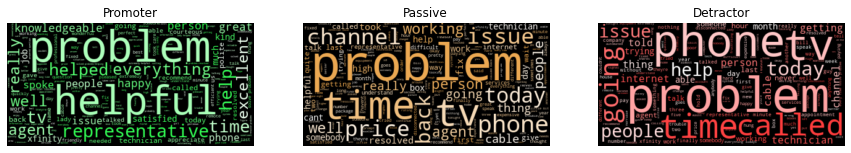

```python
## Word Cloud Side by Side:
fig, (ax1, ax2 ,ax3) = plt.subplots(1, 3,figsize=(15,5))
# fig.suptitle('Horizontally stacked subplots')
default_colors = wc.to_array()
ax1.imshow(wc.recolor(color_func=green_color_func, random_state=3),
           interpolation="bilinear")
wc.to_file("new_hope.png")
ax1.axis("off")
ax1.title.set_text('Promoter')
ax1.plot()


default_colors = wcp.to_array()
ax2.imshow(wcp.recolor(color_func=yellow_color_func, random_state=3),
           interpolation="bilinear")
wcp.to_file("new_hope_p.png")
ax2.axis("off")
ax2.title.set_text('Passive')
ax2.plot()





default_colors = wcd.to_array()
plt.figure(figsize=(10,10))
ax3.imshow(wcd.recolor(color_func=red_color_func, random_state=3),
           interpolation="bilinear")
wcd.to_file("a_new_hope.png")
ax3.axis("off")
ax3.title.set_text('Detractor')
ax3.plot()

fig.show()
```

Insight--

1- Agent Helpfulness,Knowledge is driving the Promoter Score.

2- Time,TV,Channel is a matter of concern for customer.

3- Non Resolution of Issue,Long wait time will convert a customer into Detractor.

```python
data1=df[['Phone tNPS','Phone Reason for Score']]
#data1.isnull().sum()
```

```python
dataratingtext=data1.dropna(subset=['Phone Reason for Score'])
```

```python
datarating10=dataratingtext[dataratingtext['Phone tNPS']==10]
commentRating10=datarating10['Phone Reason for Score']
CommentRating10=commentRating10.str.lower()


datarating9=dataratingtext[dataratingtext['Phone tNPS']==9]
commentRating9=datarating9['Phone Reason for Score']
CommentRating9=commentRating9.str.lower()


datarating8=dataratingtext[dataratingtext['Phone tNPS']==8]
commentRating8=datarating8['Phone Reason for Score']
CommentRating8=commentRating8.str.lower()


datarating7=dataratingtext[dataratingtext['Phone tNPS']==7]
commentRating7=datarating7['Phone Reason for Score']
CommentRating7=commentRating7.str.lower()


datarating6=dataratingtext[dataratingtext['Phone tNPS']==6]
commentRating6=datarating6['Phone Reason for Score']
CommentRating6=commentRating6.str.lower()


datarating5=dataratingtext[dataratingtext['Phone tNPS']==5]
commentRating5=datarating5['Phone Reason for Score']
CommentRating5=commentRating5.str.lower()


datarating4=dataratingtext[dataratingtext['Phone tNPS']==4]
commentRating4=datarating4['Phone Reason for Score']
CommentRating4=commentRating4.str.lower()


datarating3=dataratingtext[dataratingtext['Phone tNPS']==3]
commentRating3=datarating3['Phone Reason for Score']
CommentRating3=commentRating3.str.lower()


datarating2=dataratingtext[dataratingtext['Phone tNPS']==2]
commentRating2=datarating2['Phone Reason for Score']
CommentRating2=commentRating2.str.lower()


datarating1=dataratingtext[dataratingtext['Phone tNPS']==1]
commentRating1=datarating1['Phone Reason for Score']
CommentRating1=commentRating1.str.lower()


datarating0=dataratingtext[dataratingtext['Phone tNPS']==0]
commentRating0=datarating0['Phone Reason for Score']
CommentRating0=commentRating0.str.lower()
```

```python
# #Rating 10
# stopwords=nltk.corpus.stopwords.words('english')
# stopwords.extend(['from', 'subject', 're', 'edu', 'use', 'not', 'would', 'say', 'could', '_', 'be', 'know', 'good', 'go', 'get', 'do', 'done', 'try', 'many', 'some', 'nice', 'thank', 'think', 'see', 'rather', 'easy', 'easily', 'lot', 'lack', 'make', 'want', 'seem', 'run', 'need', 'even', 'right', 'line', 'even', 'also',
#                   'may', 'take', 'come','comcast','im','service','ive','dont','call','thats','one','didnt','still','customer','got','patient'])



# docs=CommentRating10.str.lower().str.replace('[^a-z ]','')
# def clean_sentence(text):
#     words=text.split(' ')
#     words_clean=[word for word in words if word not in stopwords]
#     return ' '.join(words_clean)
# docs_clean_10=docs.apply(clean_sentence)



# input_string=' '.join(docs_clean_10)
# wc10=WordCloud().generate(input_string)
# plt.imshow(wc10)
```

```python
# def green_color_func(word, font_size, position, orientation, random_state=None,
#                     **kwargs):
#     return "hsl(130, 100%%, %d%%)" % random.randint(60, 100)


# import random
# default_colors = wc10.to_array()
# plt.figure(figsize=(12,10))
# plt.title("Promoter Rating 10")
# plt.imshow(wc10.recolor(color_func=green_color_func, random_state=3),
#            interpolation="bilinear")
# wc10.to_file("a_new_hope_10.png")
# plt.axis("off")
# plt.figure()
# plt.title("Default colors")
# plt.imshow(default_colors, interpolation="bilinear")
# plt.axis("off")
# plt.show()
```

```python
# #Rating 9
# stopwords=nltk.corpus.stopwords.words('english')
# stopwords.extend(['from', 'subject', 're', 'edu', 'use', 'not', 'would', 'say', 'could', '_', 'be', 'know', 'good', 'go', 'get', 'do', 'done', 'try', 'many', 'some', 'nice', 'thank', 'think', 'see', 'rather', 'easy', 'easily', 'lot', 'lack', 'make', 'want', 'seem', 'run', 'need', 'even', 'right', 'line', 'even', 'also',
#                   'may', 'take', 'come','comcast','im','service','ive','dont','call','thats','one','didnt','still','customer','got','well'])


# docs=CommentRating9.str.lower().str.replace('[^a-z ]','')
# def clean_sentence(text):
#     words=text.split(' ')
#     words_clean=[word for word in words if word not in stopwords]
#     return ' '.join(words_clean)
# docs_clean_9=docs.apply(clean_sentence)


# input_string=' '.join(docs_clean_9)
# wc9=WordCloud().generate(input_string)
# plt.imshow(wc9)
```

```python
# def green_color_func(word, font_size, position, orientation, random_state=None,
#                    **kwargs):
#     return "hsl(130, 100%%, %d%%)" % random.randint(60, 100)


# import random
# default_colors = wc9.to_array()
# plt.figure(figsize=(12,10))
# plt.title("Promoter Rating 9")
# plt.imshow(wc9.recolor(color_func=green_color_func, random_state=3),
#           interpolation="bilinear")
# wc9.to_file("a_new_hope_9.png")
# plt.axis("off")
# plt.figure()
# plt.title("Default colors")
# plt.imshow(default_colors, interpolation="bilinear")
# plt.axis("off")
# plt.show()
```

### Promoter Comparison

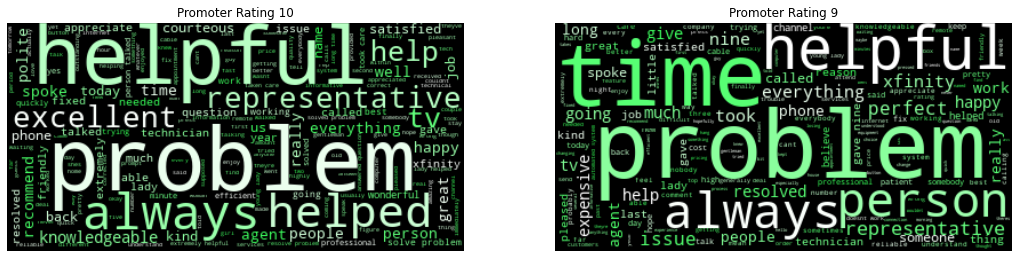

```python
## Word Cloud Side by Side:
fig, (ax1, ax2) = plt.subplots(1, 2,figsize=(18,12))

# fig.suptitle('Horizontally stacked subplots')
default_colors = wc10.to_array()
ax1.imshow(wc10.recolor(color_func=green_color_func, random_state=3),
           interpolation="bilinear")
wc10.to_file("a_new_hope_10.png")
ax1.axis("off")
ax1.title.set_text('Promoter Rating 10')
ax1.plot()


default_colors = wc9.to_array()
ax2.imshow(wc9.recolor(color_func=green_color_func, random_state=3),
           interpolation="bilinear")
wc9.to_file("a_new_hope_9.png")
ax2.axis("off")
ax2.title.set_text('Promoter Rating 9')
ax2.plot()
fig.show()
```

Insight--

Rating 10

Helpuful Agent and Representative,Knowledge of Agent and Representation(Technician),Timely Resolution is driving the NPS score as Promoter.

Rating 9

Helpfulness is Driving the Customer Promoter Sentiment.

```python
# #Rating 8
# stopwords=nltk.corpus.stopwords.words('english')
# stopwords.extend(['from', 'subject', 're', 'edu', 'use', 'not', 'would', 'say', 'could', '_', 'be', 'know', 'good', 'go', 'get', 'do', 'done', 'try', 'many', 'some', 'nice', 'thank', 'think', 'see', 'rather', 'easy', 'easily', 'lot', 'lack', 'make', 'want', 'seem', 'run', 'need', 'even', 'right', 'line', 'even', 'also',
#                   'may', 'take', 'come','comcast','im','service','ive','dont','call','thats','one','didnt','still','got','give','customer','back'])



# docs=CommentRating8.str.lower().str.replace('[^a-z ]','')
# def clean_sentence(text):
#     words=text.split(' ')
#     words_clean=[word for word in words if word not in stopwords]
#     return ' '.join(words_clean)
# docs_clean_8=docs.apply(clean_sentence)

# input_string=' '.join(docs_clean_8)
# wc8=WordCloud().generate(input_string)
# plt.imshow(wc8)
```

```python
# def green_color_func(word, font_size, position, orientation, random_state=None,
#                    **kwargs):
#     return "hsl(34, 79%%, %d%%)" % random.randint(60, 100)


# import random
# default_colors = wc8.to_array()
# plt.figure(figsize=(12,10))
# plt.title("Custom colors")
# plt.imshow(wc8.recolor(color_func=green_color_func, random_state=3),
#           interpolation="bilinear")
# wc10.to_file("a_new_hope_8.png")
# plt.axis("off")
# plt.figure()
# plt.title("Default colors")
# plt.imshow(default_colors, interpolation="bilinear")
# plt.axis("off")
# plt.show()
```

```python
# #Rating 7
# stopwords=nltk.corpus.stopwords.words('english')
# stopwords.extend(['from', 'subject', 're', 'edu', 'use', 'not', 'would', 'say', 'could', '_', 'be', 'know', 'good', 'go', 'get', 'do', 'done', 'try', 'many', 'some', 'nice', 'thank', 'think', 'see', 'rather', 'easy', 'easily', 'lot', 'lack', 'make', 'want', 'seem', 'run', 'need', 'even', 'right', 'line', 'even', 'also',
#                   'may', 'take', 'come','comcast','im','service','ive','dont','call','thats','one','didnt','still','got'])


# docs=CommentRating7.str.lower().str.replace('[^a-z ]','')
# def clean_sentence(text):
#     words=text.split(' ')
#     words_clean=[word for word in words if word not in stopwords]
#     return ' '.join(words_clean)
# docs_clean_7=docs.apply(clean_sentence)




# input_string=' '.join(docs_clean_7)
# wc7=WordCloud().generate(input_string)
# plt.imshow(wc7)
```

```python
# def green_color_func(word, font_size, position, orientation, random_state=None,
#                    **kwargs):
#     return "hsl(34, 79%%, %d%%)" % random.randint(60, 100)


# import random
# default_colors = wc7.to_array()
# plt.figure(figsize=(12,10))
# plt.title("Custom colors")
# plt.imshow(wc7.recolor(color_func=green_color_func, random_state=3),
#           interpolation="bilinear")
# wc10.to_file("a_new_hope_7.png")
# plt.axis("off")
# plt.figure()
# plt.title("Default colors")
# plt.imshow(default_colors, interpolation="bilinear")
# plt.axis("off")
# plt.show()
```

### Passive Comparison

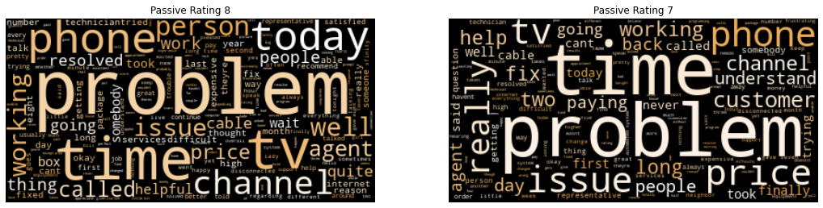

```python
## Word Cloud Side by Side:
fig, (ax1, ax2) = plt.subplots(1, 2,figsize=(18,12))
# fig.suptitle('Horizontally stacked subplots')
default_colors = wc8.to_array()
ax1.imshow(wc8.recolor(color_func=green_color_func, random_state=3),
           interpolation="bilinear")
wc8.to_file("a_new_hope_8.png")
ax1.axis("off")
ax1.title.set_text('Passive Rating 8')
ax1.plot()


default_colors = wc7.to_array()
plt.figure(figsize=(10,10))
ax2.imshow(wc7.recolor(color_func=green_color_func, random_state=3),
           interpolation="bilinear")
wc7.to_file("a_new_hope_7.png")
ax2.axis("off")
ax2.title.set_text('Passive Rating 7')
ax2.plot()

fig.show()
```

Insight--

TV,Channel and Cable related product issues and agent related issues such as problem resolution,time are affecting customer satisfaction.

### Detractor Comparison

```python
# #Rating 6
# stopwords=nltk.corpus.stopwords.words('english')
# stopwords.extend(['from', 'subject', 're', 'edu', 'use', 'not', 'would', 'say', 'could', '_', 'be', 'know', 'good', 'go', 'get', 'do', 'done', 'try', 'many', 'some', 'nice', 'thank', 'think', 'see', 'rather', 'easy', 'easily', 'lot', 'lack', 'make', 'want', 'seem', 'run', 'need', 'even', 'right', 'line', 'even', 'also',
#                   'may', 'take', 'come','comcast','im','service','ive','dont','call','thats','one','didnt','still','cant','got','customer'])



# docs=CommentRating6.str.lower().str.replace('[^a-z ]','')
# def clean_sentence(text):
#     words=text.split(' ')
#     words_clean=[word for word in words if word not in stopwords]
#     return ' '.join(words_clean)
# docs_clean_6=docs.apply(clean_sentence)



# input_string=' '.join(docs_clean_6)
# wc6=WordCloud().generate(input_string)
# plt.imshow(wc6)
```

```python
# def red_color_func(word, font_size, position, orientation, random_state=None,
#                   **kwargs):
#     return "hsl(0, 100%%, %d%%)" % random.randint(60, 100)

# import random
# default_colors = wc6.to_array()
# plt.figure(figsize=(12,10))
# plt.title("Custom colors")
# plt.imshow(wc6.recolor(color_func=red_color_func, random_state=3),
#           interpolation="bilinear")
# wc6.to_file("a_new_hope_6.png")
# plt.axis("off")
# plt.figure()
# plt.title("Default colors")
# plt.imshow(default_colors, interpolation="bilinear")
# plt.axis("off")
# plt.show()
```

```python
# #Rating 5
# stopwords=nltk.corpus.stopwords.words('english')
# stopwords.extend(['from', 'subject', 're', 'edu', 'use', 'not', 'would', 'say', 'could', '_', 'be', 'know', 'good', 'go', 'get', 'do', 'done', 'try', 'many', 'some', 'nice', 'thank', 'think', 'see', 'rather', 'easy', 'easily', 'lot', 'lack', 'make', 'want', 'seem', 'run', 'need', 'even', 'right', 'line', 'even', 'also',
#                   'may', 'take', 'come','comcast','im','service','ive','dont','call','thats','one','didnt','still','customer','got','back','cant'])


# docs=CommentRating5.str.lower().str.replace('[^a-z ]','')
# def clean_sentence(text):
#     words=text.split(' ')
#     words_clean=[word for word in words if word not in stopwords]
#     return ' '.join(words_clean)
# docs_clean_5=docs.apply(clean_sentence)




# input_string=' '.join(docs_clean_5)
# wc5=WordCloud().generate(input_string)
# plt.imshow(wc5)
```

```python
# def red_color_func(word, font_size, position, orientation, random_state=None,
#                   **kwargs):
#     return "hsl(0, 100%%, %d%%)" % random.randint(60, 100)

# import random
# default_colors = wc5.to_array()
# plt.figure(figsize=(12,10))
# plt.title("Custom colors")
# plt.imshow(wc5.recolor(color_func=red_color_func, random_state=3),
#           interpolation="bilinear")
# wc5.to_file("a_new_hope_5.png")
# plt.axis("off")
# plt.figure()
# plt.title("Default colors")
# plt.imshow(default_colors, interpolation="bilinear")
# plt.axis("off")
# plt.show()
```

```python
# #Rating 4

# stopwords=nltk.corpus.stopwords.words('english')
# stopwords.extend(['from', 'subject', 're', 'edu', 'use', 'not', 'would', 'say', 'could', '_', 'be', 'know', 'good', 'go', 'get', 'do', 'done', 'try', 'many', 'some', 'nice', 'thank', 'think', 'see', 'rather', 'easy', 'easily', 'lot', 'lack', 'make', 'want', 'seem', 'run', 'need', 'even', 'right', 'line', 'even', 'also',
#                   'may', 'take', 'come','comcast','im','service','ive','dont','call','thats','one','didnt','still','customer','back','last'])



# docs=CommentRating4.str.lower().str.replace('[^a-z ]','')
# def clean_sentence(text):
#     words=text.split(' ')
#     words_clean=[word for word in words if word not in stopwords]
#     return ' '.join(words_clean)
# docs_clean_4=docs.apply(clean_sentence)


# input_string=' '.join(docs_clean_4)
# wc4=WordCloud().generate(input_string)
# plt.imshow(wc4)
```

```python
# def red_color_func(word, font_size, position, orientation, random_state=None,
#                   **kwargs):
#     return "hsl(0, 100%%, %d%%)" % random.randint(60, 100)

# import random
# default_colors = wc4.to_array()
# plt.figure(figsize=(12,10))
# plt.title("Custom colors")
# plt.imshow(wc4.recolor(color_func=red_color_func, random_state=3),
#           interpolation="bilinear")
# wc4.to_file("a_new_hope_4.png")
# plt.axis("off")
# plt.figure()
# plt.title("Default colors")
# plt.imshow(default_colors, interpolation="bilinear")
# plt.axis("off")
# plt.show()
```

```python
# #Rating 3
# stopwords=nltk.corpus.stopwords.words('english')
# stopwords.extend(['from', 'subject', 're', 'edu', 'use', 'not', 'would', 'say', 'could', '_', 'be', 'know', 'good', 'go', 'get', 'do', 'done', 'try', 'many', 'some', 'nice', 'thank', 'think', 'see', 'rather', 'easy', 'easily', 'lot', 'lack', 'make', 'want', 'seem', 'run', 'need', 'even', 'right', 'line', 'even', 'also',
#                   'may', 'take', 'come','comcast','im','service','ive','dont','call','thats','one','didnt','still','back'])


# docs=CommentRating3.str.lower().str.replace('[^a-z ]','')
# def clean_sentence(text):
#     words=text.split(' ')
#     words_clean=[word for word in words if word not in stopwords]
#     return ' '.join(words_clean)
# docs_clean_3=docs.apply(clean_sentence)




# input_string=' '.join(docs_clean_3)
# wc3=WordCloud().generate(input_string)
# plt.imshow(wc3)
```

```python
# def red_color_func(word, font_size, position, orientation, random_state=None,
#                   **kwargs):
#     return "hsl(0, 100%%, %d%%)" % random.randint(60, 100)

# import random
# default_colors = wc3.to_array()
# plt.figure(figsize=(12,10))
# plt.title("Custom colors")
# plt.imshow(wc3.recolor(color_func=red_color_func, random_state=3),
#           interpolation="bilinear")
# wc3.to_file("a_new_hope_3.png")
# plt.axis("off")
# plt.figure()
# plt.title("Default colors")
# plt.imshow(default_colors, interpolation="bilinear")
# plt.axis("off")
# plt.show()
```

```python
# #Rating 2
# stopwords=nltk.corpus.stopwords.words('english')
# stopwords.extend(['from', 'subject', 're', 'edu', 'use', 'not', 'would', 'say', 'could', '_', 'be', 'know', 'good', 'go', 'get', 'do', 'done', 'try', 'many', 'some', 'nice', 'thank', 'think', 'see', 'rather', 'easy', 'easily', 'lot', 'lack', 'make', 'want', 'seem', 'run', 'need', 'even', 'right', 'line', 'even', 'also',
#                   'may', 'take', 'come','comcast','im','service','ive','dont','call','thats','one','didnt','still','customer','back','got'])


# docs=CommentRating2.str.lower().str.replace('[^a-z ]','')
# def clean_sentence(text):
#     words=text.split(' ')
#     words_clean=[word for word in words if word not in stopwords]
#     return ' '.join(words_clean)
# docs_clean_2=docs.apply(clean_sentence)



# input_string=' '.join(docs_clean_2)
# wc2=WordCloud().generate(input_string)
# plt.imshow(wc2)
```

```python
# def red_color_func(word, font_size, position, orientation, random_state=None,
#                   **kwargs):
#     return "hsl(0, 100%%, %d%%)" % random.randint(60, 100)

# import random
# default_colors = wc2.to_array()
# plt.figure(figsize=(12,10))
# plt.title("Custom colors")
# plt.imshow(wc2.recolor(color_func=red_color_func, random_state=3),
#           interpolation="bilinear")
# wc2.to_file("a_new_hope_2.png")
# plt.axis("off")
# plt.figure()
# plt.title("Default colors")
# plt.imshow(default_colors, interpolation="bilinear")
# plt.axis("off")
# plt.show()
```

```python
# #Rating 1
# stopwords=nltk.corpus.stopwords.words('english')
# stopwords.extend(['from', 'subject', 're', 'edu', 'use', 'not', 'would', 'say', 'could', '_', 'be', 'know', 'good', 'go', 'get', 'do', 'done', 'try', 'many', 'some', 'nice', 'thank', 'think', 'see', 'rather', 'easy', 'easily', 'lot', 'lack', 'make', 'want', 'seem', 'run', 'need', 'even', 'right', 'line', 'even', 'also',
#                   'may', 'take', 'come','comcast','im','service','ive','dont','call','thats','one','didnt','still','customer','able','said','day'])



# docs=CommentRating1.str.lower().str.replace('[^a-z ]','')
# def clean_sentence(text):
#     words=text.split(' ')
#     words_clean=[word for word in words if word not in stopwords]
#     return ' '.join(words_clean)
# docs_clean_1=docs.apply(clean_sentence)



# input_string=' '.join(docs_clean_1)
# wc1=WordCloud().generate(input_string)
# plt.imshow(wc1)
```

```python
# def red_color_func(word, font_size, position, orientation, random_state=None,
#                   **kwargs):
#     return "hsl(0, 100%%, %d%%)" % random.randint(60, 100)

# import random
# default_colors = wc1.to_array()
# plt.figure(figsize=(12,10))
# plt.title("Custom colors")
# plt.imshow(wc1.recolor(color_func=red_color_func, random_state=3),
#           interpolation="bilinear")
# wc1.to_file("a_new_hope_1.png")
# plt.axis("off")
# plt.figure()
# plt.title("Default colors")
# plt.imshow(default_colors, interpolation="bilinear")
# plt.axis("off")
# plt.show()
```

```python
# #Rating 0
# stopwords=nltk.corpus.stopwords.words('english')
# stopwords.extend(['from', 'subject', 're', 'edu', 'use', 'not', 'would', 'say', 'could', '_', 'be', 'know', 'good', 'go', 'get', 'do', 'done', 'try', 'many', 'some', 'nice', 'thank', 'think', 'see', 'rather', 'easy', 'easily', 'lot', 'lack', 'make', 'want', 'seem', 'run', 'need', 'even', 'right', 'line', 'even', 'also',
#                   'may', 'take', 'come','comcast','im','service','ive','dont','call','thats','one','didnt','still','customer','got','going','said','called'])



# docs=CommentRating0.str.lower().str.replace('[^a-z ]','')
# def clean_sentence(text):
#     words=text.split(' ')
#     words_clean=[word for word in words if word not in stopwords]
#     return ' '.join(words_clean)
# docs_clean_0=docs.apply(clean_sentence)




# input_string=' '.join(docs_clean_0)
# wc0=WordCloud().generate(input_string)
# plt.imshow(wc0)
```

```python
# def red_color_func(word, font_size, position, orientation, random_state=None,
#                   **kwargs):
#     return "hsl(0, 100%%, %d%%)" % random.randint(60, 100)

# import random
# default_colors = wc0.to_array()
# plt.figure(figsize=(12,10))
# plt.title("Custom colors")
# plt.imshow(wc0.recolor(color_func=red_color_func, random_state=3),
#           interpolation="bilinear")
# wc0.to_file("a_new_hope_0.png")
# plt.axis("off")
# plt.figure()
# plt.title("Default colors")
# plt.imshow(default_colors, interpolation="bilinear")
# plt.axis("off")
# plt.show()
```

[figure not shown]

```python
import matplotlib.pyplot as plt
%matplotlib inline
from PIL import Image


## Word Cloud Side by Side:
fig, ((ax1,ax2,ax3),(ax4,ax5,ax6)) = plt.subplots(2, 3,figsize=(15,5))


default_colors = wc6.to_array()
ax1.imshow(wc6.recolor(color_func=red_color_func, random_state=3),
           interpolation="bilinear")
wc6.to_file("a_new_hope_6.png")
ax1.axis("off")
ax1.title.set_text('Detractor Rating 6')
ax1.plot()
fig.show()


default_colors = wc5.to_array()
plt.figure(figsize=(10,10))
ax2.imshow(wc5.recolor(color_func=red_color_func, random_state=3),
           interpolation="bilinear")
wc5.to_file("a_new_hope_5.png")
ax2.axis("off")
ax2.title.set_text('Detractor Rating 5')
ax2.plot()
fig.show()


default_colors = wc4.to_array()
ax3.imshow(wc4.recolor(color_func=red_color_func, random_state=3),
           interpolation="bilinear")
wc4.to_file("a_new_hope_4.png")
ax3.axis("off")
ax3.title.set_text('Detractor Rating 4')
ax3.plot()
fig.show()


default_colors = wc3.to_array()
ax4.imshow(wc3.recolor(color_func=red_color_func, random_state=3),
           interpolation="bilinear")
wc3.to_file("a_new_hope_3.png")
ax4.axis("off")
ax4.title.set_text('Detractor Rating 3')
ax4.plot()
fig.show()


default_colors = wc2.to_array()
ax5.imshow(wc2.recolor(color_func=red_color_func, random_state=3),
           interpolation="bilinear")
wc2.to_file("a_new_hope_2.png")
ax5.axis("off")
ax5.title.set_text('Detractor Rating 2')
ax5.plot()
fig.show()


default_colors = wc1.to_array()
ax6.imshow(wc1.recolor(color_func=red_color_func, random_state=3),
           interpolation="bilinear")
wc1.to_file("a_new_hope_1.png")
ax6.axis("off")
ax6.title.set_text('Detractor Rating 1')
ax6.plot()
fig.show()


#default_colors = wc0.to_array()
#ax0.imshow(wc0.recolor(color_func=green_color_func, random_state=3),
 #          interpolation="bilinear")
#wc0.to_file("a_new_hope_0.png")
#ax0.axis("off")
#ax0.plot()
#plt.show()
```

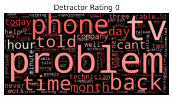

```python
def red_color_func(word, font_size, position, orientation, random_state=None,
                   **kwargs):
    return "hsl(0, 100%%, %d%%)" % random.randint(60, 100)

import random
default_colors = wc0.to_array()
plt.figure(figsize=(5,3))
plt.title("Detractor Rating 0")
plt.imshow(wc0.recolor(color_func=red_color_func, random_state=3),
           interpolation="bilinear")
wc0.to_file("a_new_hope_0.png")
plt.axis("off")
plt.figure()
#plt.title("Default colors")
#plt.imshow(default_colors, interpolation="bilinear")
plt.axis("off")
plt.show()
```